# Tema 1. Introducción a la programación en R

Programación en Tecnologías de la Información Geográfica · Máster Universitario en Tecnologías de la Información Geográfica

Author

Verónica Cruz Alonso y Paloma Ruiz Benito

Published

06/10/2026

[figure not shown]

# 1 ¿Qué es R?

🎯 **R** es un lenguaje de programación dinámico creado para análisis estadístico y el entorno donde se ejecuta.

*Dinámico* significa que el código es interpretado en el momento de la ejecución.

Sus características principales son:

- Código libre (gratuito).
- Herramienta flexible y potente.
- Permite portar bloques de código que es replicable en otras plataformas.
- Existen ejemplos para muchos análisis.
- Hecho por y para la comunidad.

[figure not shown]

Infografía sobre la historia de R.

Es el lenguaje de programación **más utilizado en el mundo científico**. Se alinea muy bien con los principios de la **ciencia**.

| La ciencia… | R… |
| --- | --- |
| debería ser libre | es gratuito (libre) |
| debería ser abierta | es de código abierto |
| debería ser colaborativa | es colaborativo |
| avanza el conocimiento | se actualiza constantemente |
| debe ser replicable | permite replicar análisis |

[figure not shown]

> ¡La mayor parte de los usuarios de R no son programadores!

La comunidad de usuarios de R es muy grande y activa en internet, a nivel nacional e internacional.

[figure not shown]

[figure not shown]

## 1.1 Usos y aplicaciones

Aunque R es un lenguaje popular utilizado por muchos programadores, es especialmente eficaz para el **análisis de datos**, la **inferencia estadística** y los **algoritmos de aprendizaje automático**.

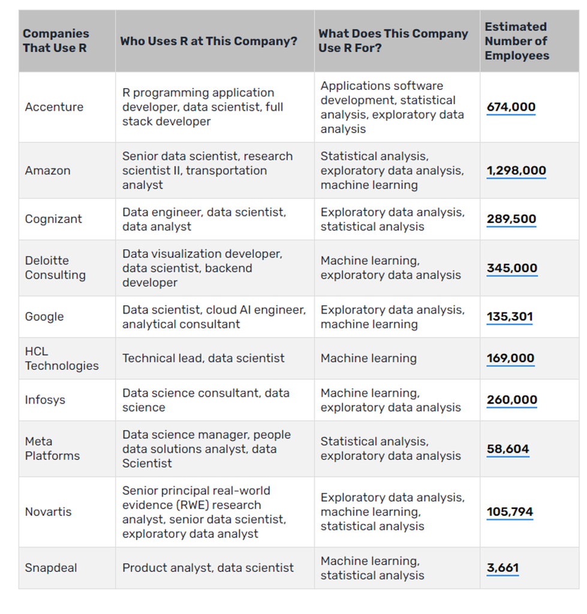

https://careerkarma.com/blog/who-uses-r/

Aunque no te interese tanto el análisis de datos, R puede darte algunas oportunidades laborales.

[figure not shown]

Aplicaciones de R. https://data-flair.training/blogs/r-applications/

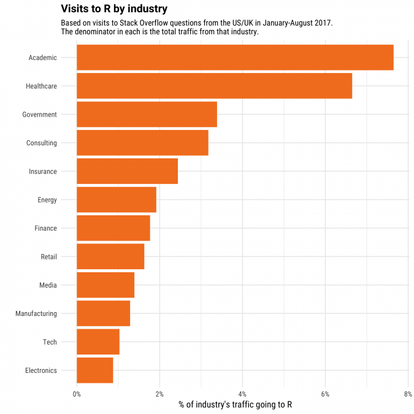

Visitas a preguntas de R por sector. https://stackoverflow.blog/2017/10/10/impressive-growth-r/

- [The Manfred Tech Career Report 2025](https://www.getmanfred.com/en/developer-career-report)
- [Dice Salary Survey](https://www.dice.com/technologists/ebooks/tech-salary-report/salaries-by-skill.html)

## 1.2 Ejemplos de visualización de datos

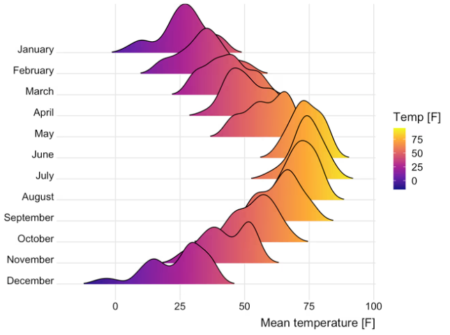

Gráfico de densidad en crestas. https://www.datanovia.com/en/blog/elegant-visualization-of-density-distribution-in-r-using-ridgeline/

[figure not shown]

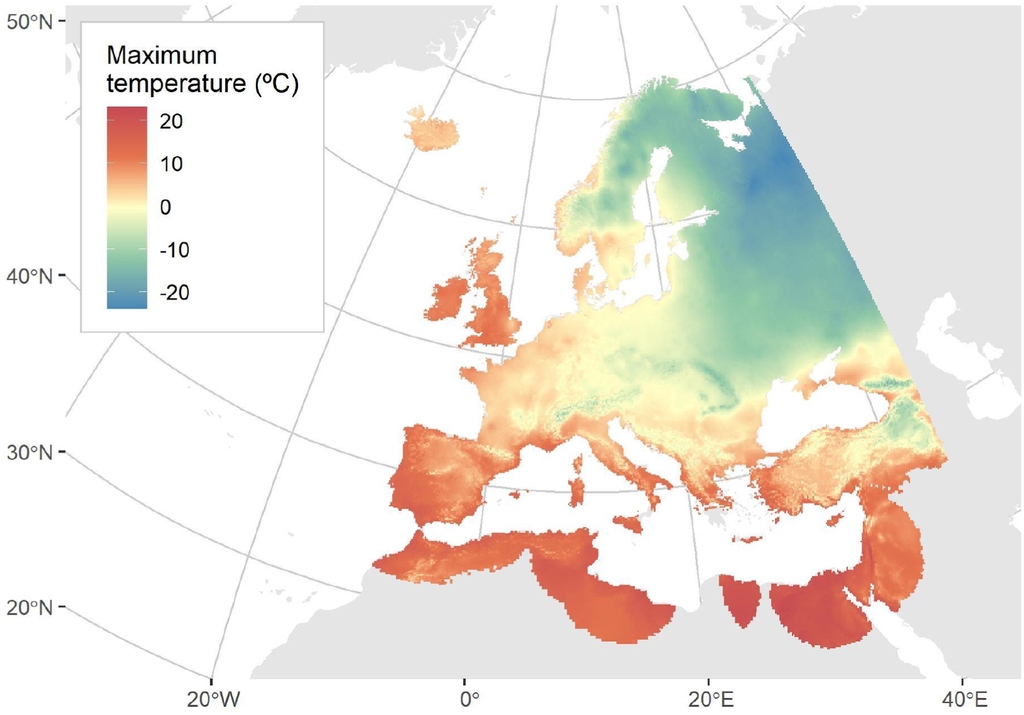

Mapa ráster de temperatura máxima en Europa. Cruz-Alonso et al. (2023), *Environmental Modelling & Software*, https://doi.org/10.1016/j.envsoft.2023.105627

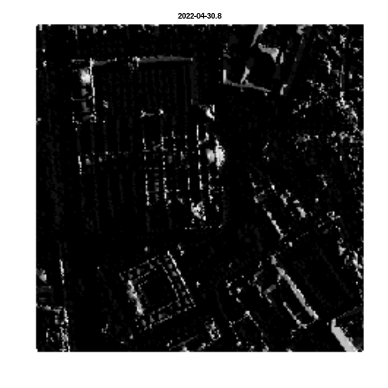

Mapa de sombra de la ciudad de Sevilla. https://github.com/Pakillo/CityShadeMapper

# 2 ¿Qué es RStudio?

🎯 **RStudio** es un entorno de desarrollo integrado (IDE) para programar en R gratuito y de código abierto.

[figure not shown]

## 2.1 ¿Por qué usar RStudio?

- El re**saltado de sintaxis**, autocompletado de código y sangría inteligente.
- Permite **ejecutar el código de R** directamente desde el editor de código.
- Tiene **documentación** y soporte integrado.
- Tiene un **asistente IA** integrado basado en un LLM (*Large Languaje Model*).
- Permite la **administración sencilla** de múltiples directorios de trabajo mediante proyectos.
- Permite la navegación en espacios de trabajo y **visualizar datos**.
- Tiene un depurador interactivo de código para diagnosticar y **corregir errores rápidamente**.
- Tiene integradas **herramientas de desarrollo** y acepta complementos.
- Permite la generación de **documentos dinámicos** con Quarto.
- Actúa como **cliente** para otros programas, por ejemplo Git y SVN.

—————————————————————————————————————————————

## 2.2 📝 Ejercicio

Abre R y RStudio. ¿Qué diferencias observas?

Puedes usar la “cheatsheet” de Rstudio en el Aula Virtual

—————————————————————————————————————————————

RStudio tiene cuatro zonas diferenciadas:

- El editor de código: sirve para escribir y guardar scripts, resalta la sintaxis, autocompleta código y permite ejecutar líneas o fragmentos.
- La consola: donde se ejecuta el código. Muestra los resultados de forma inmediata.
- El navegador del espacio de trabajo, con el entorno –*environment*- y el historial de comandos.
- La ventana de salidas o *outputs*: muestra archivos del proyecto, gráficos generados, paquetes, ayuda…

## 2.3 ¿Qué es un archivo .R?

🎯 Un archivo `.R` es muy parecido a un .txt, pero no exactamente igual.

- Los editores y entornos como RStudio reconocen `.R` como archivo de código en R y ofrecen resaltado de sintaxis, autocompletado, indentación y otras ayudas.
- Los sistemas de control de versiones lo identifican como *script* ejecutable en R.
- Según la configuración, al hacer doble clic puede abrirse directamente en R o RStudio.

# 3 R como lenguaje de programación

> ¿Qué te resulta más complejo de entender, el código binario o el lenguaje humano?

—————————————————————————————————————————————

## 3.1 📝 Ejercicio

Lee el apartado “lenguajes de programación”, “algoritmos” y “programas”: https://estadistica-dma.ulpgc.es/cursoR4ULPGC/15-programacionR.html.

Responde a estas preguntas:

- ¿Qué diferencia a los lenguajes de alto y bajo nivel?
- ¿Qué es un algoritmo? y ¿un programa?

—————————————————————————————————————————————

Podemos entender que tenemos:

- **Lenguajes de alto nivel:** instrucciones más próximas al lenguaje humano. Por ejemplo: C, Fortran, Java, Python, R y Matlab.
- **Lenguajes de bajo nivel:** instrucciones más próximas al código binario.

Además, R es un lenguaje de **programación dinámico o interpretado** que puede ejecutarse en Linux, Mac y Windows porque existen intérpretes disponibles en estos sistemas operativos. R se considera un **lenguaje de programación** en sí mismo que va más allá del análisis estadístico.

💡 Aunque existen *interfaces* gráficas como RCommander, donde a través de botones puedes indicar a la consola qué hacer, es prioritario aprender a escribir R sin IA como profesional de las TIG.

R es también un **lenguaje *orientado a objetos***. La principal razón para utilizar la programación **orientada a objetos (*OOP*)** es el *polimorfismo* (del latín «muchas formas»). Facilita el uso de una misma función con **distintos tipos de datos de entrada**. Para entenderlo, vamos a ejecutar juntos el siguiente código:

```r
summary(iris$Species)
```

```
    setosa versicolor  virginica
        50         50         50
```

```r
summary(iris$Sepal.Length)
```

```
   Min. 1st Qu.  Median    Mean 3rd Qu.    Max.
  4.300   5.100   5.800   5.843   6.400   7.900
```

`summary()` es una función que realiza un resumen del objeto que se indica. Podrías pensar que `summary()` utiliza una serie de sentencias `if-else` en función del tipo de datos de entrada. Sin embargo, un sistema de programación orientada a objetos permite a cualquier desarrollador ampliar la interfaz creando implementaciones para nuevos tipos de datos de entrada según su clase.

```r
#install.packages("sloop")
library(sloop)
ftype(summary)
```

```
[1] "S3"      "generic"
```

```r
methods(summary)
```

```
 [1] summary.aov                         summary.aovlist*
 [3] summary.aspell*                     summary.check_packages_in_dir*
 [5] summary.connection                  summary.data.frame
 [7] summary.Date                        summary.default
 [9] summary.difftime                    summary.ecdf*
[11] summary.factor                      summary.free1way*
[13] summary.glm                         summary.infl*
[15] summary.lm                          summary.loess*
[17] summary.manova                      summary.matrix
[19] summary.mlm*                        summary.nls*
[21] summary.packageStatus*              summary.POSIXct
[23] summary.POSIXlt                     summary.ppr*
[25] summary.prcomp*                     summary.princomp*
[27] summary.proc_time                   summary.rlang:::list_of_conditions*
[29] summary.rlang_error*                summary.rlang_message*
[31] summary.rlang_trace*                summary.rlang_warning*
[33] summary.srcfile                     summary.srcref
[35] summary.stepfun                     summary.stl*
[37] summary.table                       summary.tukeysmooth*
[39] summary.warnings
see '?methods' for accessing help and source code
```

En los sistemas OOP, el **tipo de un objeto** se denomina *clase*, y una **implementación específica** para una clase se conoce como *método*. En términos generales, una clase define las características de un objeto (¿qué es?) y los métodos describen las acciones que dicho objeto puede realizar (¿qué hace?).

La programación orientada a objetos, utilizada por lenguajes como Java o Python, ha sido el paradigma de programación más popular en las últimas décadas.

```r
especie = "Pinus sylvestris"
diametro = 32
altura = 18

arbol <- data.frame(especie, diametro, altura) #arbol es un objeto

# Método específico para objetos de clase "arbol"
calcular.arbol <- function(x) {
  x$diametro * x$altura
}

# Aplicamos el método al objeto
calcular.arbol(arbol)
```

```
[1] 576
```

**🚀Avanzado🚀:** Podríamos incluir una función genérica que hace que la función se comporte de una manera distinta en función del tipo de objeto.

```r
calcular <- function(x) {
  UseMethod("calcular")
  }

calcular.arbol <- function(x) {
  x$diametro * x$altura
  }
```

**R es un lenguaje multiparadigma:** permite programación imperativa, funcional y orientada a objetos. La programación orientada a objetos organiza el código en torno a objetos que pertenecen a determinadas clases. R dispone de varios sistemas de objetos, entre ellos S3, S4 y RC, siendo **S3 el más sencillo y utilizado en R base**.

**S4** es más formal y estricto: las clases, atributos y métodos están definidos explícitamente. Se usa bastante en algunos paquetes científicos, especialmente en Bioconductor y objetos complejos.

**RC (Reference Classes)** se parece más al modelo clásico de Java o Python: los objetos tienen campos y métodos y pueden modificar su propio estado. Es mucho menos habitual en el uso cotidiano de R.

Lo interesante de nuestro ejemplo es que **`calcular()`** no contiene realmente el cálculo. piensa: *“Este objeto es un `arbol`, así que tengo que buscar `calcular.arbol()`.”* Por tanto, el flujo es:

**objeto `arbol` → clase `"arbol"` → `calcular()` → `calcular.arbol()` → diámetro × altura**

Esto ilustra muy bien **S3 y el despacho de métodos**

# 4 Ciencia de datos y reproducibilidad

La ciencia de datos es el proceso por el que los datos brutos se transforman en comprensión y conocimiento.

> ¿Qué programas utilizáis para ello?

Dentro de este proceso, la programación puede ser la herramienta que se utilice para todo. Y en ella se centra esta asignatura.

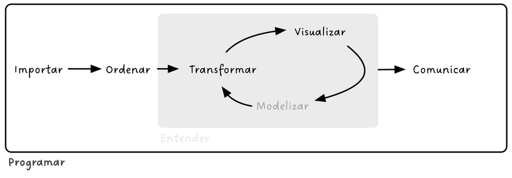

Esquema del proceso de ciencia de datos. Modificado de: https://r4ds.hadley.nz/intro.htm

—————————————————————————————————————————————

## 4.1 📝 Ejercicio

1. ¿Qué programa de trabajo utilizáis? Discutelo con un compañero.

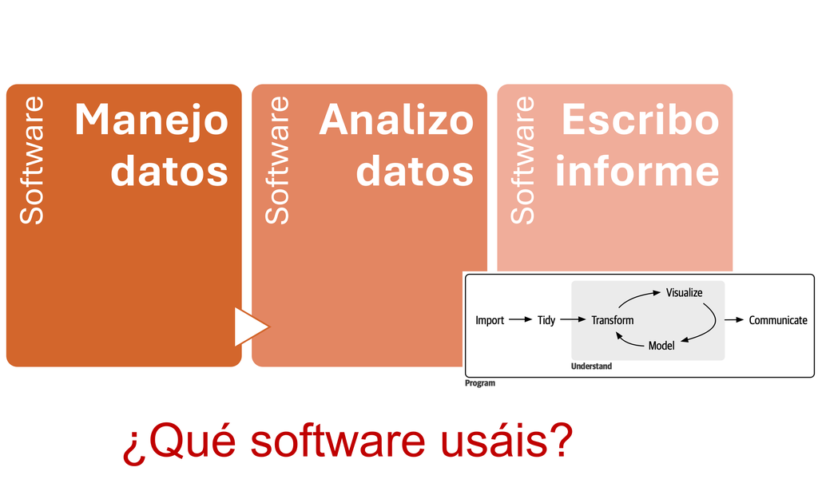

2. Por parejas, discutid las ventajas e inconvenientes de usar un lenguaje de programación para todo el procedimiento. Encontrad al menos **5 ventajas y 2 inconvenientes**.
3. Encontrad una **definición de trabajo reproducible**.

—————————————————————————————————————————————

Leed la [guía para la Ciencia Reproducible](https://book.the-turing-way.org/reproducible-research/reproducible-research/) de *The Turing Way*. Revisad por parejas vuestras definiciones y ventajas: ¿añadiríais algo más?

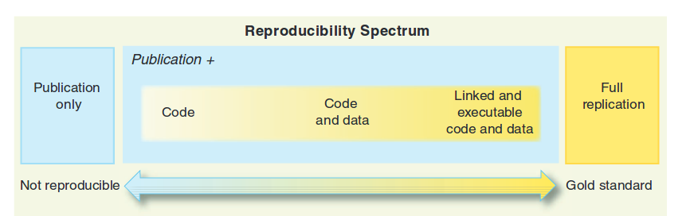

Espectro de reproducibilidad. Peng 2011. *Science*. https://doi.org/10.1126/science.1213847

En ciencia de datos, es reproducible cuando:

**Reproducible:** Un resultado es reproducible cuando los mismos pasos de análisis realizados sobre el mismo conjunto de datos producen sistemáticamente el mismo resultado.

**Replicable:** Un resultado es replicable cuando el mismo análisis realizado sobre diferentes conjuntos de datos produce resultados cualitativamente similares.

**Robusto:** Un resultado es robusto cuando el mismo conjunto de datos se somete a distintos flujos de trabajo de análisis para responder a la misma pregunta de investigación (por ejemplo, un *script* escrito en R y otro en Python) y se obtiene un resultado cualitativamente similar o idéntico. Los resultados robustos demuestran que el trabajo no depende de las particularidades del lenguaje de programación elegido para realizar el análisis.

**Generalizable:** La combinación de hallazgos replicables y robustos nos permite obtener resultados generalizables. Pero será necesario realizar muchos más pasos para determinar hasta qué punto el trabajo es aplicable a los distintos aspectos de la pregunta de investigación. La generalización es un paso importante para comprender que el resultado no depende de un conjunto de datos concreto ni de una versión específica del análisis.

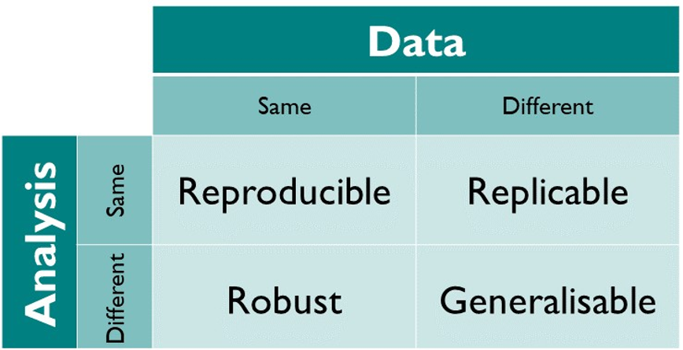

[The turning way](https://book.the-turing-way.org/reproducible-research/reproducible-research/).

## 4.2 ¿Por qué debemos preocuparnos por la reproducibilidad?

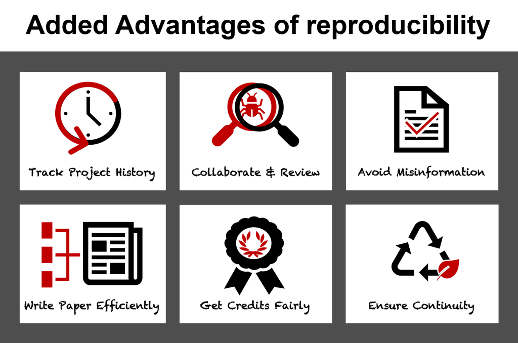

[The turning way.](https://book.the-turing-way.org/reproducible-research/reproducible-research/)

| Ventajas | Desventajas |
| --- | --- |
| Registro completo de la historia y metodología | Mayor esfuerzo técnico y documental |
| Facilita colaboración, revisión y publicación validada | Requiere habilidades no siempre disponibles o incentivadas |
| Aumenta confianza, visibilidad y reconocimiento académico | Sobrecarga inicial de trabajo (tests, documentación) |
| Optimiza la redacción de productos escritos |  |
| Mejora manejo de datos, entornos y calidad del código |  |
| Asegura continuidad del proyecto a lo largo del tiempo |  |
| Promueve prácticas abiertas y accesibles en investigación |  |

En la academia estas ventajas permiten verificar los resultados, colaborar y avanzar la ciencia. En el mundo de la empresa permite entregar resultados fiables, flujos de trabajo reutilizables y regulados.

—————————————————————————————————————————————

## 4.3 📝 Ejercicio

Responde a las preguntas verdadero / falso disponibles en el aula virtual

—————————————————————————————————————————————

# 5 Bibliografía recomendada

[figure not shown]

*R for Data Science*. https://r4ds.hadley.nz/.

[figure not shown]

*Hands-On Programming with R*. https://rstudio-education.github.io/hopr/

[figure not shown]

*Advanced R*. http://adv-r.had.co.nz/

[figure not shown]

*Concepts, Techniques, and Models of Computer Programming.*

[figure not shown]

*The Pragmatic Programmer*.

### 5.0.1 ¿Quién responde a mis dudas?

- [RStudio User Guide](https://docs.posit.co/ide/user)
- [*ROpenSci*](https://ropensci.org) y [Tools for reproducible research](https://kbroman.org/Tools4RR)
- [Cheatsheet de buenas prácticas en R](https://rstudio.github.io/cheatsheets/R-best-practice.pdf)
- [Posit Recipes](https://posit.cloud/learn/recipes) y en general [Posit Resources](https://posit.co/resources)
- Ayuda > Cheat Sheets
- [Stack Overflow: plataforma de preguntas y respuestas para programadores profesionales y aficionados](https://stackoverflow.com)
- Comunidad de RStudio/Posit
- [GitHub copilot](https://github.com/features/copilot)
- [ChatGPT](https://chatgpt.com) y similares
- Slack del [Grupo de Ecoinformática de la AEET](https://ecoinfaeet.github.io/website/index.html)
- [Discusiones del repositorio del curso de GitHub](https://github.com/DatSciR/ciencia_datos/discussions/2)
- Para dudas relacionadas con errores de paquetes: repositorio de GitHub del paquete en cuestión (p. ej. https://github.com/tidyverse/dplyr/issues)
- Pedir ayuda utilizando ejemplos reproducibles con {reprex}.